# Лабораторная работа №7

Учёт физических параметров сети

Ко Антон Геннадьевич

antonkosakh@gmail.com

Российский университет дружбы народов

2026-09-04

# Информация

## Докладчик

- Ко Антон Геннадьевич
- студент
- Российский университет дружбы народов им. П. Лумумбы
- 1132221551@rudn.ru
- https://SenDerMen04.github.io/ru/

## Цель работы

Получить навыки работы с физической рабочей областью Packet Tracer, а также учесть физические параметры сети.

## Выполнение работы

Перейдём в физическую рабочую область Packet Tracer и присвоим название городу — Moscow (рис. #fig:002):

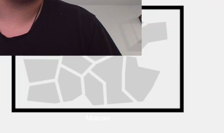

Открытие физической рабочей области Packet Tracer и присвоение названия городу

Щёлкнув на изображение города, мы видим изображение здания. Присвоим ему название Donskaya и добавим здание для территории Pavlovskaya (рис. #fig:003):

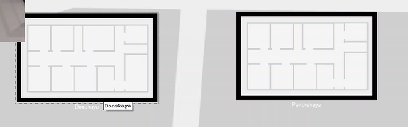

Присвоение зданию названия Donskaya и добавление здания для территории Pavlovskaya

Щёлкнув на изображение здания Donskaya, переместим изображение, обозначающее серверное помещение, в него (рис. #fig:004):

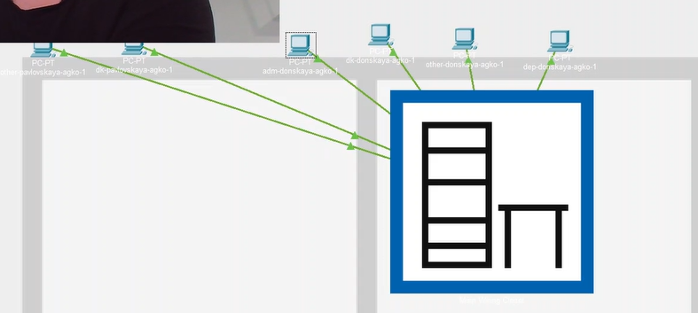

Перемещение изображения, обозначающего серверное помещение, внутрь здания

Затем, щёлкнув на изображение серверной, мы видим отображение серверных стоек. Переместим коммутатор `msk-pavlovskaya-agko-sw-1` (рис. #fig:005) и два оконечных устройства `dk-pavlovskaya-1` и `other-pavlovskaya-1` (рис. #fig:006) на территорию Pavlovskaya, используя меню “Move” физической рабочей области Packet Tracer.

[figure not shown]

Перемещение коммутатора msk-pavlovskaya-agko-sw-1 на территорию Pavlovskaya

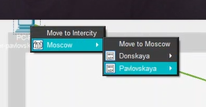

Перемещение двух оконечных устройств (dk-pavlovskaya-1 и other-pavlovskaya-1) на территорию Pavlovskaya

Вернувшись в логическую рабочую область Packet Tracer, выполним ping с коммутатора `msk-donskaya-agko-sw-1` на коммутатор `msk-pavlovskaya-agko-sw-1` и убедимся в работоспособности соединения (рис. #fig:007):

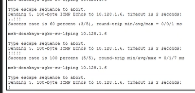

Пинг с коммутатора msk-donskaya-agko-sw-1 на коммутатор msk-pavlovskaya-agko-sw-1 (проверка работоспособности соединения)

Далее в меню “Options” → “Preferences” во вкладке “Interface” активируем разрешение на учёт физических характеристик среды передачи (Enable Cable Length Effects) (рис. #fig:008):

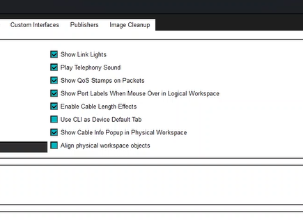

Активация разрешения на учёт физических характеристик среды передачи

Теперь в физической рабочей области Packet Tracer разместим две территории на расстоянии более 100 м друг от друга (рис. #fig:009):

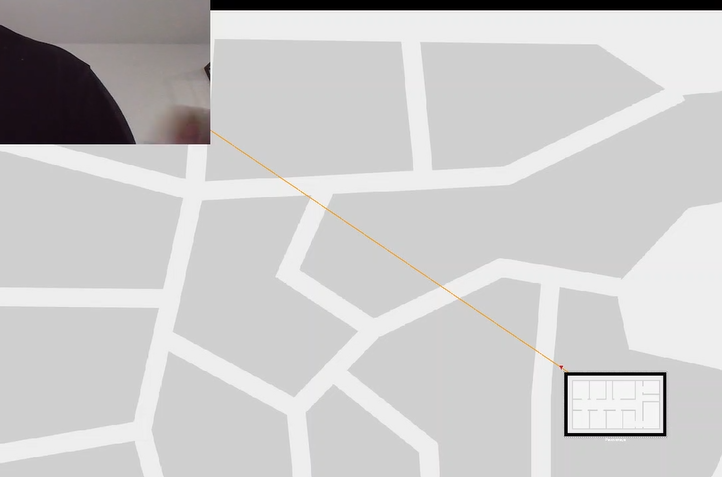

Размещение двух территорий на расстоянии более 100 м друг от друга

Вернувшись в логическую рабочую область Packet Tracer, выполним ping с коммутатора `msk-donskaya-agko-sw-1` на коммутатор `msk-pavlovskaya-agko-sw-1` и убедимся в неработоспособности соединения (рис. #fig:010):

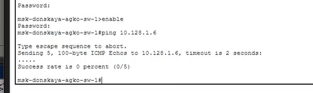

Пинг с коммутатора msk-donskaya-agko-sw-1 на коммутатор msk-pavlovskaya-agko-sw-1 (проверка неработоспособности соединения)

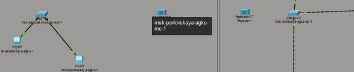

Удаление соединения, добавление двух повторителей и присвоение им названий

Переместим `msk-pavlovskaya-agko-mc-1` на территорию Pavlovskaya (в физической рабочей области Packet Tracer) (рис. #fig:013):

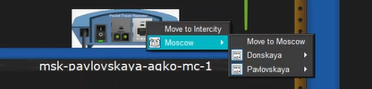

Перемещение msk-pavlovskaya-agko-mc-1 на территорию Pavlovskaya

Теперь подключим коммутатор `msk-donskaya-agko-sw-1` к `msk-donskaya-agko-mc-1` по витой паре, `msk-donskaya-agko-mc-1` и `msk-pavlovskaya-agko-mc-1` — по оптоволокну, `msk-pavlovskaya-agko-sw-1` к `msk-pavlovskaya-agko-mc-1` — по витой паре (рис. #fig:014):

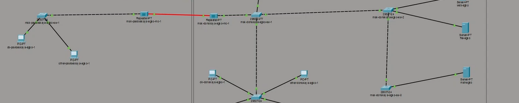

Подключение коммутаторов через повторители по витой паре и оптоволокну

Убедимся в работоспособности соединения между `msk-donskaya-agko-sw-1` и `msk-pavlovskaya-agko-sw-1` (рис. #fig:015):

[figure not shown]

Проверка работоспособности соединения после добавления повторителей

## Вывод

В ходе выполнения лабораторной работы мы получили навыки работы с физической рабочей областью Packet Tracer, а также научились учитывать физические параметры сети (расстояние между устройствами, типы кабелей) с использованием повторителей для увеличения дальности передачи сигнала.